# Reaction Time - Liberals

Nicolas Restrepo

1/29/2020

## Analysis of the Reaction Time Study (Liberal Sample)

```r
# Packages
library(tidyverse)
library(knitr)
library(kableExtra)
library(ggrepel)
library(gridExtra)
library(haven)
library(lavaan)
library(lme4)
library(nlme)
library(stargazer)
library(broom)
library(psych)
library(brms)
library(plotly)
library(sjPlot)
theme_set(theme_light())
```

I’m going to begin by loading in the data.

```r
# Load in the data
rt_liberal <- read_csv("rt_liberal.csv")
```

As a first step I am going to check how people did in the attention checks.

```r
# Delete unnecessary rows
rt_liberal <- rt_liberal[-(1:2),]

# How many people passed the attention checks?
rt_liberal <- rt_liberal %>%
  mutate(passed = if_else(att_1 == "Harmless (K)" & att_2 == "Immoral (J)" & att_3 == "Harmful (J)", 1, 0))

rt_liberal %>%
  group_by(passed) %>%
  summarise(n())
```

```
## # A tibble: 2 x 2
##   passed `n()`
##    <dbl> <int>
## 1      0     5
## 2      1    92
```

```r
# Filter out the people who failed the attention checks
rt_liberal <- rt_liberal %>%
  filter(passed == 1)
```

From the 100 surveys I sent out, 97 were completed. There were three in which the respondents reported technical problems. From these 97 respondents, 92 passed all the attention checks. I am going to go ahead and continue this preliminary analysis with these 92 cases.

Now, I am going to run some quick diagnostics. I am mostly looking for overly short responses, which would indicate either a misclick or random key stroke. Before that I will do a fair amount of reshaping.

```r
# Only keep reaction time data and put it in the long format
rt_liberal_times <- rt_liberal %>%
  select(ends_with("Page Submit")) %>%
  mutate(ids = 1:92) %>%
  pivot_longer(1:50, names_to = "scenario", values_to = "reaction_time") %>%
  mutate(scenario = str_remove(scenario, "_t_Page Submit$"))

# Get summary statistics
gd <- rt_liberal_times %>%
  mutate(reaction_time = as.numeric(reaction_time)) %>%
  group_by(scenario) %>%
  summarise(avg = mean(reaction_time),
            st_dv = sd(reaction_time),
            med = median(reaction_time)) %>%
  mutate(ci_lower = avg - 1.96*st_dv,
         ci_upper = avg + 1.96*st_dv)

# Create a quick summary table
rt_liberal_times %>%
  mutate(reaction_time = as.numeric(reaction_time)) %>%
  summarise(avg = mean(reaction_time),
            stv = sd(reaction_time)) %>%
  mutate(ci_lower = avg - 1.96*stv,
         ci_upper = avg + 1.96*stv) %>%
  kable(.) %>%
  kable_styling()
```

| avg | stv | ci_lower | ci_upper |
| --- | --- | --- | --- |
| 3.395085 | 1.34303 | 0.7627465 | 6.027423 |

```r
# Now check for exceedingly low responses
sum(rt_liberal_times$reaction_time < 1)
```

```
## [1] 4
```

```r
sum(rt_liberal_times$reaction_time > 5.58)
```

```
## [1] 302
```

```r
sum(rt_liberal_times$reaction_time > 9)
```

```
## [1] 19
```

I need to think more about what to do with the observations that are considerably above the mean (for example those above 9). However, I am pretty sure that those 4 observations under a second are misclicks. I will go ahead replace their values for the median of their respective scenario. There is probably a more informed way to do this, but I think this will suffice for the preliminary analysis.

```r
# Which are the responses below 1 second?
which(rt_liberal_times$reaction_time < 1)
```

```
## [1]  767 1119 1514 2757
```

```r
# Replace them with the appropriate median
rt_liberal_times[767,] <- gd[gd$scenario=="i_ccr",4]
rt_liberal_times[1119,] <- gd[gd$scenario=="i_msn",4]
rt_liberal_times[1514,] <- gd[gd$scenario=="i_ayc",4]
rt_liberal_times[2757,] <- gd[gd$scenario=="i_elb",4]
```

Having replaced those values, I am going to produce some descriptive plots.

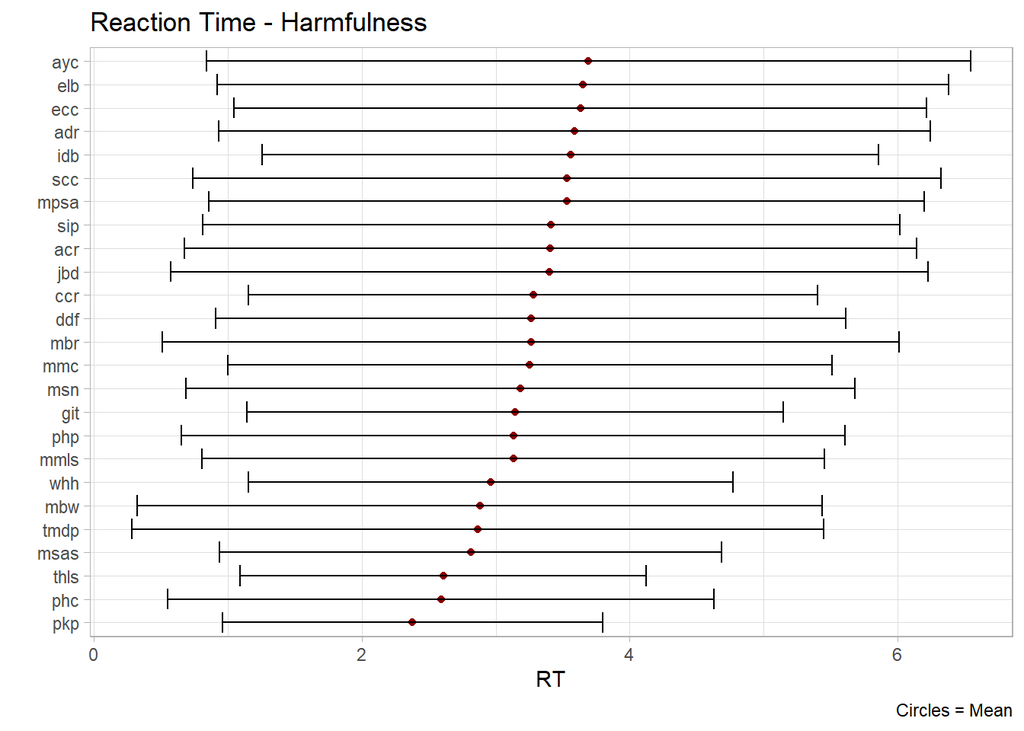

```r
# Now let's plot harm

# Keep only harm questions

gdh <- gd[str_which(gd$scenario, "h_"),]

# Plot harm questions
gdh %>%
  mutate(scenario = str_remove(scenario, "h_")) %>%
  ggplot(aes(x = reorder(scenario, avg), y = avg)) +
  geom_point(col = "darkred", fill = "darkred") +
  geom_errorbar(aes(ymin = ci_lower, ymax = ci_upper)) +
  coord_flip() +
  labs(x = "",
       y = "RT",
       title = "Reaction Time - Harmfulness",
       caption = "Circles = Mean")
```

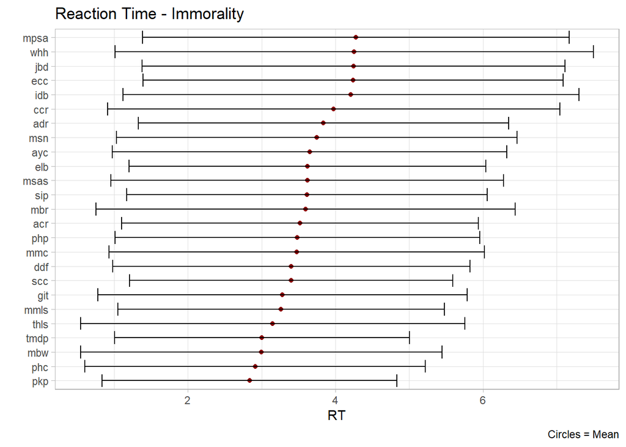

```r
# Get only Immorality questions
gdi <- gd[str_which(gd$scenario, "i_"),]

# Plot harm questions
gdi %>%
  mutate(scenario = str_remove(scenario, "i_")) %>%
  ggplot(aes(x = reorder(scenario, avg), y = avg)) +
  geom_point(col = "darkred", fill = "darkred") +
  geom_errorbar(aes(ymin = ci_lower, ymax = ci_upper)) +
  coord_flip() +
  labs(x = "",
       y = "RT",
       title = "Reaction Time - Immorality",
       caption = "Circles = Mean")
```

At first glance, the confidence intervals look quite wide. It is important to think whether the variation in the data is coming from real empirical variability or whether the instrument is too noisy. I certainly need to spend more time thinking about the latter.

The most prototypical scenarios have consistently the lowest reaction times. However, at this point, it does not seem that distance from the prototype would be very informative when predicting reaction time. Let’s dig deeper.

Let’s try to recreate Gray and Keeney’s reaction time plot.

```r
# Create a manageable wide dataframe

rtw <- rt_liberal %>%
  select(ends_with("Page Submit")) %>%
  mutate(ids = 1:92)

# Create a long dataframe for harm

d_long_harm <- rtw %>%
  select(ids, starts_with("h_")) %>%
  pivot_longer(2:26, names_to = "scenario", values_to = "reaction_time_harm") %>%
  mutate(scenario = str_remove(scenario, "_t_Page Submit$")) %>%
  mutate(scenario = str_remove(scenario, "^h_"))

# Create a long dataframe for immorality

d_long_imm <- rtw %>%
  select(ids, starts_with("i_")) %>%
  pivot_longer(2:26, names_to = "scenario", values_to = "reaction_time_imm") %>%
  mutate(scenario = str_remove(scenario, "_t_Page Submit$")) %>%
  mutate(scenario = str_remove(scenario, "^i_"))

# Now join them

d_long <- d_long_harm %>%
  mutate(reaction_time_imm = d_long_imm$reaction_time_imm) %>%
  mutate(reaction_time_harm = as.numeric(reaction_time_harm),
         reaction_time_imm = as.numeric(reaction_time_imm))

# Let's get some information about the events in there

# Load dataset with the deflections

selected_events <- read_csv("data/full_events.csv")
```

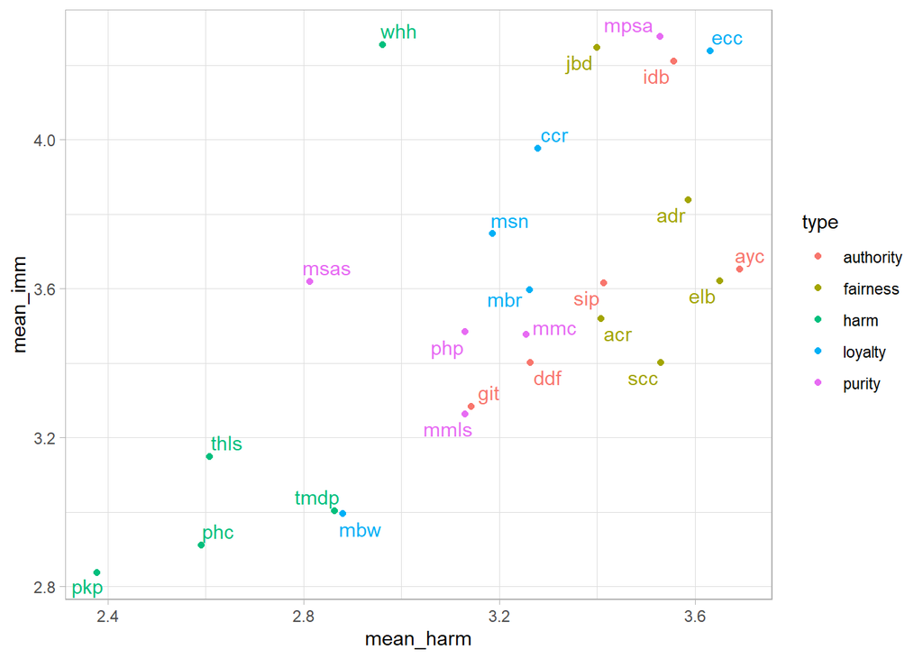

```r
# Create column for abreviations

events <- c("phc",
            "pkp",
            "tmdp",
            "adr",
            "elb",
            "acr",
            "jbd",
            "scc",
            "ddf",
            "git",
            "idb",
            "ayc",
            "sip",
            "ecc",
            "ccr",
            "mbr",
            "msn",
            "mbw",
            "php",
            "mmc",
            "mmls",
            "msas",
            "mpsa",
            "whh",
            "thls")

# Create new column

events_def <- selected_events %>%
  mutate(scenario = events) %>%
  select(scenario, def, type, 5:33)

# Add to long dataset

d_long <- d_long %>%
  left_join(events_def, by = "scenario")

# Get the averages so we can plot them

dsl <- d_long %>%
  group_by(scenario, type) %>%
  summarise(mean_harm = mean(reaction_time_harm),
            mean_imm = mean(reaction_time_imm)) %>%
  ungroup()


dsl %>%
  ggplot(aes(x = mean_harm, y = mean_imm, col = type)) +
  geom_point() +
  geom_text_repel(aes(label = scenario), show.legend = F)
```

There seems to be a strong positive relationship between reaction times in both sections. This is encouraging because it shows that the “practice effect” might not be as strong as previously expected. We can also reproduce the plot by Gray and Keeney quite reliably. I still think that length and complexity are doing a lot of work here. For example, employee conspires with competitor is a complex and long sentence that has consistently high reaction time. The same applies for “married person has sex with adulterer”.

I want to check how length correlates with reaction time.

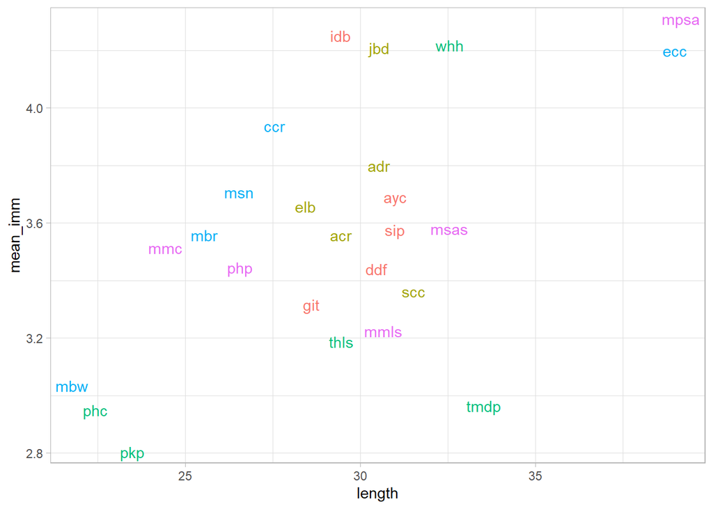

```r
# Name the scenarios with the full length

dsl <- dsl %>%
  mutate(full_string = case_when(scenario == "acr" ~ "an_athlete_cheats_their_rival",
                                 scenario == "adr" ~ "an_athlete_deceives_the_referee",
                                 scenario == "ayc" ~ "an_athlete_yells_at_their_coach",
                                 scenario == "ccr" ~ "a_coach_cheers_for_the_rival",
                                 scenario == "ddf" ~ "a_daughter_disobeys_her_father",
                                 scenario == "ecc" ~ "an_employee_conspires_with_a_competitor",
                                 scenario == "elb" ~ "an_employee_lies_to_the_boss",
                                 scenario == "git" ~ "a_girl_interrupts_her_teacher",
                                 scenario == "idb" ~ "an_intern_disobeys_their_boss",
                                 scenario == "jbd" ~ "a_judge_befriends_the_defendant",
                                 scenario == "mbr" ~ "a_man_betrays_his_relative",
                                 scenario == "mbw" ~ "a_man_betrays_his_wife",
                                 scenario == "mmc" ~ "a_man_marries_his_cousin",
                                 scenario == "mmls" ~ "a_man_makes_love_to_his_sister",
                                 scenario == "mpsa" ~ "a_married_man_has_sex_with_an_adulterer",
                                 scenario == "msas" ~ "a_mother_sexually_arouses_her_son",
                                 scenario == "msn" ~ "a_mayor_slanders_a_neighbor",
                                 scenario == "phc" ~ "a_person_hurts_a_child",
                                 scenario == "php" ~ "a_person_hires_a_prostitute",
                                 scenario == "pkp" ~ "a_person_kills_a_person",
                                 scenario == "scc" ~ "a_student_cheats_their_classmate",
                                 scenario == "sip" ~ "a_student_insults_the_professor",
                                 scenario == "thls" ~ "a_teacher_hits_a_lazy_student",
                                 scenario == "whh" ~ "a_wife_hits_her_forgetful_husband",
                                 scenario == "tmdp" ~ "a_teenager_mocks_a_disabled_person"))

# Add the short versions again for the plot

dsl <- dsl %>%
  mutate(length = str_count(full_string))

# Now let's plot length + reaction time for immorality

dsl %>%
  ggplot(aes(x = length, y = mean_imm, col = type)) +
  geom_text_repel(aes(label = scenario), show.legend = F)
```

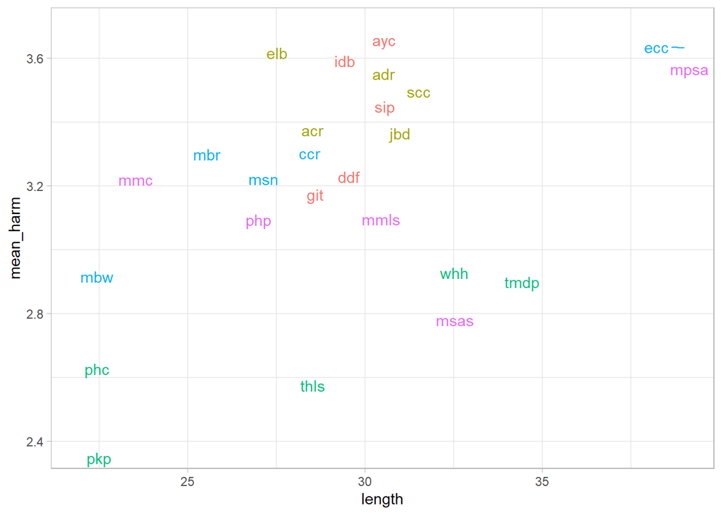

```r
# Now let's plot length + reaction time for harm

dsl %>%
  ggplot(aes(x = length, y = mean_harm, col = type)) +
  geom_text_repel(aes(label = scenario), show.legend = F)
```

## Exploring Distances

Now, I am going to begin looking at distances from the “prototypical” moral trangressions and will analyze whether these are informative for predicting reaction time. Let’s first calculate the distances.

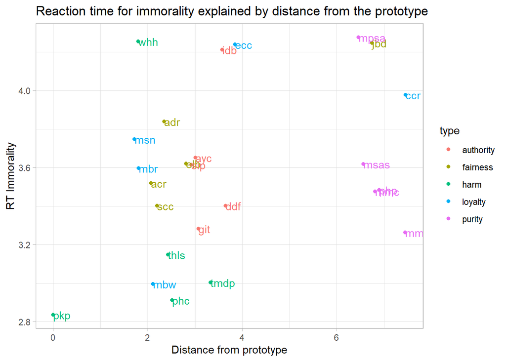

```r
# Create function to calculate the euclidean distance in three-dimensional space

events_values <- events_def %>%
  select(scenario, op, be, bp)

eucl_dist_pkp <- function(x) {
    op <-  events_values[x, 2]
    be <-  events_values[x, 3]
    bp <-  events_values[x, 4]

   # Formula
  # The values of the prototype are always the ones the events are compared against
  distance <- sqrt((0.95 - op)^2 + ((-4.26) - be)^2 + (1.95 - bp)^2)
   return(as.double(distance))
}


distances_pkp <- map_dbl(1:25, eucl_dist_pkp)

events_values_pkp <- events_values %>%
  cbind(distances_pkp) %>%
  select(scenario, distances_pkp)

# Join values with the long dataset

dsl <- dsl %>%
  left_join(events_values_pkp, by = "scenario")

# Plot reaction time for immorality and distances from prototype.

dsl %>%
  ggplot(aes(x = distances_pkp, y = mean_imm, col = type)) +
  geom_point() +
  geom_text(aes(label = scenario), hjust = 0, show.legend = F) +
  labs(x = "Distance from prototype",
       y = "RT Immorality",
       title = "Reaction time for immorality explained by distance from the prototype")
```

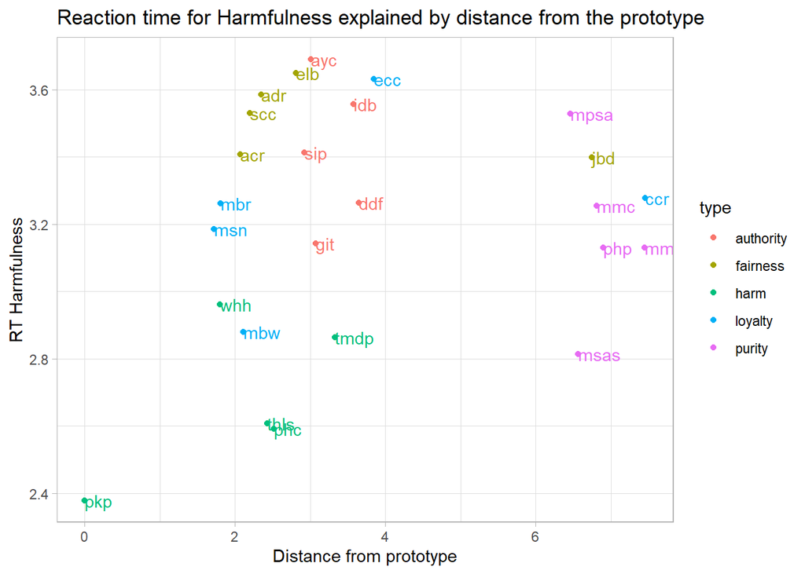

```r
# Plot reaction time for harm and distances from prototype.

dsl %>%
  ggplot(aes(x = distances_pkp, y = mean_harm, col = type)) +
  geom_point() +
  geom_text(aes(label = scenario), hjust = 0, show.legend = F) +
  labs(x = "Distance from prototype",
       y = "RT Harmfulness",
       title = "Reaction time for Harmfulness explained by distance from the prototype")
```

There does seem to be a positive association but it does not appear to be particularly strong. I am going to explore another way of defining distance: choosing a different prototype where the object is more vulnerable. As our previous analysis shows, increases in the object’s potency lead to decreases in the event’s severity. In this calculation, then, we are wrongly “penalizing” the scenarios that have more vulnerable patients than the one that features in our prototype - i.e. person -, which is fairly neutral. In the next part, then, I will choose “person hurts a child” as the prototype.

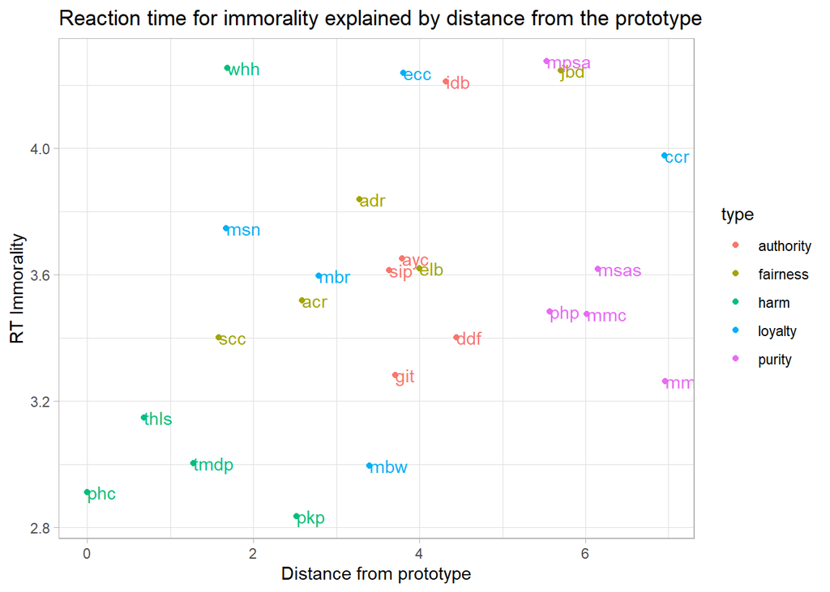

```r
# Create new function with Person hurts child as the prototype

eucl_dist_phc <- function(x) {
    op <-  events_values[x, 2]
    be <-  events_values[x, 3]
    bp <-  events_values[x, 4]

   # Formula
  # The values of the prototype are always the ones the events are compared against
  distance <- sqrt(((-1.14) - op)^2 + ((-3.17) - be)^2 + (1.06 - bp)^2)
   return(as.double(distance))
}


distances_phc <- map_dbl(1:25, eucl_dist_phc)

events_values_phc <- events_values %>%
  cbind(distances_phc) %>%
  select(scenario, distances_phc)

# Join values with the long dataset

dsl <- dsl %>%
  left_join(events_values_phc, by = "scenario")

# Plot reaction time for immorality and distances from prototype.

dsl %>%
  ggplot(aes(x = distances_phc, y = mean_imm, col = type)) +
  geom_point() +
  geom_text(aes(label = scenario), hjust = 0, show.legend = F) +
  labs(x = "Distance from prototype",
       y = "RT Immorality",
       title = "Reaction time for immorality explained by distance from the prototype")
```

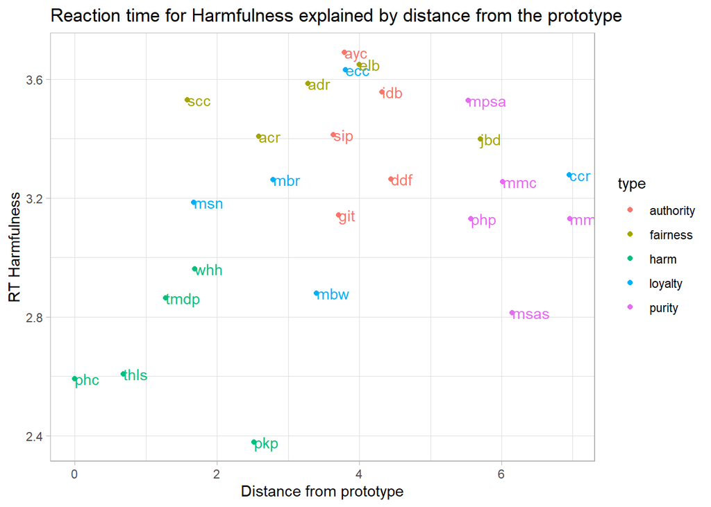

```r
# Plot reaction time for harm and distances from prototype.

dsl %>%
  ggplot(aes(x = distances_phc, y = mean_harm, col = type)) +
  geom_point() +
  geom_text(aes(label = scenario), hjust = 0, show.legend = F) +
  labs(x = "Distance from prototype",
       y = "RT Harmfulness",
       title = "Reaction time for Harmfulness explained by distance from the prototype")
```

If we calculate distance from “person hurts a child”, we also get positive associations. Now, that we have these distances we can try to run some models with them.

## Preliminary models

Let’s try to see how some preliminary regressions would look like.

```r
# Let's first tidy the data a bit
# Get the lengths and put them in the main dataset

lengths <- dsl %>%
  select(scenario, length, distances_phc, distances_pkp)

d_long <- d_long %>%
  select(1:16) %>%
  left_join(lengths, by = "scenario")

# Scale the dataframe

d_long_scaled <-
  d_long %>%
  mutate_at(c("ids", "type", "scenario"), ~as.factor(.)) %>%
  mutate_if(is.numeric, scale)

# Now let's some models
#first let's check the relationship between immorality and harm

m1 <- lmer(reaction_time_harm ~ 1 + reaction_time_imm + length + (1 | ids) + (1 | scenario),
           data = d_long_scaled)

tab_model(m1, p.val = ("kr"))
```

|  | reaction time harm |  |  |
| --- | --- | --- | --- |
| Predictors | Estimates | CI | p |
| (Intercept) | -0.00 | -0.12 – 0.12 | 1.000 |
| reaction_time_imm | 0.17 | 0.13 – 0.21 | **<0.001** |
| length | 0.10 | 0.00 – 0.19 | **0.039** |
| Random Effects |  |  |  |
| σ<sup>2</sup> | 0.71 |  |  |
| τ<sub>00</sub> <sub>ids</sub> | 0.15 |  |  |
| τ<sub>00</sub> <sub>scenario</sub> | 0.05 |  |  |
| ICC | 0.22 |  |  |
| N <sub>ids</sub> | 92 |  |  |
| N <sub>scenario</sub> | 25 |  |  |
| Observations | 2300 |  |  |
| Marginal R<sup>2</sup> / Conditional R<sup>2</sup> | 0.047 / 0.252 |  |  |

```r
m2 <- lmer(reaction_time_imm ~ 1 + reaction_time_harm + length + (1 | ids) + (1 | scenario),
           data = d_long_scaled)

tab_model(m2, p.val = ("kr"))
```

|  | reaction time imm |  |  |
| --- | --- | --- | --- |
| Predictors | Estimates | CI | p |
| (Intercept) | -0.00 | -0.13 – 0.13 | 1.000 |
| reaction_time_harm | 0.15 | 0.11 – 0.19 | **<0.001** |
| length | 0.17 | 0.07 – 0.26 | **0.001** |
| Random Effects |  |  |  |
| σ<sup>2</sup> | 0.67 |  |  |
| τ<sub>00</sub> <sub>ids</sub> | 0.18 |  |  |
| τ<sub>00</sub> <sub>scenario</sub> | 0.05 |  |  |
| ICC | 0.25 |  |  |
| N <sub>ids</sub> | 92 |  |  |
| N <sub>scenario</sub> | 25 |  |  |
| Observations | 2300 |  |  |
| Marginal R<sup>2</sup> / Conditional R<sup>2</sup> | 0.061 / 0.300 |  |  |

```r
m3 <- lmer(reaction_time_imm ~ 1 + distances_phc + length + (1 | ids) + (1 | scenario),
           data = d_long_scaled)

tab_model(m3, p.val = ("kr"))
```

|  | reaction time imm |  |  |
| --- | --- | --- | --- |
| Predictors | Estimates | CI | p |
| (Intercept) | -0.00 | -0.14 – 0.14 | 1.000 |
| distances_phc | 0.09 | -0.01 – 0.19 | 0.072 |
| length | 0.17 | 0.07 – 0.27 | **0.001** |
| Random Effects |  |  |  |
| σ<sup>2</sup> | 0.68 |  |  |
| τ<sub>00</sub> <sub>ids</sub> | 0.24 |  |  |
| τ<sub>00</sub> <sub>scenario</sub> | 0.05 |  |  |
| ICC | 0.30 |  |  |
| N <sub>ids</sub> | 92 |  |  |
| N <sub>scenario</sub> | 25 |  |  |
| Observations | 2300 |  |  |
| Marginal R<sup>2</sup> / Conditional R<sup>2</sup> | 0.042 / 0.331 |  |  |

```r
m4 <- lmer(reaction_time_harm ~ 1 + distances_phc + length + (1 | ids) + (1 | scenario),
           data = d_long_scaled)

tab_model(m4, p.val = ("kr"))
```

|  | reaction time harm |  |  |
| --- | --- | --- | --- |
| Predictors | Estimates | CI | p |
| (Intercept) | -0.00 | -0.14 – 0.14 | 1.000 |
| distances_phc | 0.08 | -0.02 – 0.18 | 0.121 |
| length | 0.12 | 0.02 – 0.21 | **0.021** |
| Random Effects |  |  |  |
| σ<sup>2</sup> | 0.72 |  |  |
| τ<sub>00</sub> <sub>ids</sub> | 0.21 |  |  |
| τ<sub>00</sub> <sub>scenario</sub> | 0.05 |  |  |
| ICC | 0.27 |  |  |
| N <sub>ids</sub> | 92 |  |  |
| N <sub>scenario</sub> | 25 |  |  |
| Observations | 2300 |  |  |
| Marginal R<sup>2</sup> / Conditional R<sup>2</sup> | 0.022 / 0.287 |  |  |

I want to draw attention to a couple of things here. First, reaction time of harm reliably predicts reaction time in immorality. This is not trivial. Given that harm comes later, this coefficient tells us that the practice effect is perhaps not as strong as previously thought. Maybe the instrument is getting at some underlying opinions, beyond reading ability and familiarity with the instrument.